# Data Load

```python
import pandas as pd
df_ad_performance = pd.read_csv("https://storage.googleapis.com/datalynn-datasets/interview-challenge/technology/Adobe_Advertising_Optimization/AdPerformance.csv")
df_audio_demographics = pd.read_csv("https://storage.googleapis.com/datalynn-datasets/interview-challenge/technology/Adobe_Advertising_Optimization/AudienceDemographics.csv")
```

## Question 1:

Given the AdPerformance table, perform an exploratory analysis on ad campaigns across different channels. Derive insights on which channels are yielding the best return on investment. Visualize the correlation between AdSpend, Impressions, Clicks, and Conversions.

## Solution:

### Hints:

1. Start by getting a descriptive summary of the data.
2. Group by Channel to aggregate metrics and calculate the return on investment (ROI) for each channel.
3. Use a heatmap to visualize the correlation between AdSpend, Impressions, Clicks, and Conversions.

```
  Channel        ROI
0  Mobile  66.808930
1     Web  59.374816
```

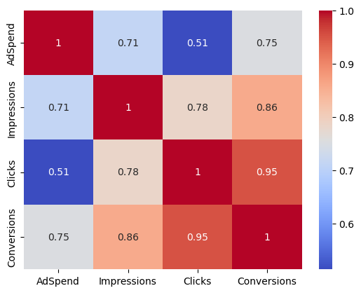

```python
import pandas as pd
import matplotlib.pyplot as plt
import seaborn as sns
# Calculating ROI for each channel
# ROI = (Conversions/AdSpend) * 100
df_ad_performance['ROI'] = (df_ad_performance['Conversions'] / df_ad_performance['AdSpend']) * 100
channel_roi = df_ad_performance.groupby('Channel').agg({'ROI': 'mean'}).reset_index()

print(channel_roi)

# Visualizing correlation
correlation = df_ad_performance[['AdSpend', 'Impressions', 'Clicks', 'Conversions']].corr()
sns.heatmap(correlation, annot=True, cmap="coolwarm")
plt.show()
```

### Summary

This solution helps in understanding the ad performance across different channels by looking at the return on investment (ROI). The heatmap will provide insights into how different metrics are correlated with each other.

## Question 2:

We suspect that not all campaigns are equally effective for different age ranges. From the AudienceDemographics and AdPerformance tables, identify which age range shows the highest conversion rate for each campaign. Based on this analysis, suggest how to adjust the advertising strategy for different campaigns to target optimal age ranges.

## Solution:

### Hints:

1. Join AudienceDemographics with AdPerformance on CampaignID.
2. Group by CampaignID and AgeRange to calculate the conversion rate for each combination.
3. Identify the age range with the highest conversion rate for each campaign.

```python
# Joining the two tables
df_combined = pd.merge(df_ad_performance, df_audio_demographics, on='CampaignID')

# Calculate conversion rate by AgeRange and Campaign
df_combined['ConversionRate'] = df_combined['Conversions'] / df_combined['Clicks']
age_conversion = df_combined.groupby(['CampaignID', 'AgeRange']).agg({'ConversionRate': 'mean'}).reset_index()

# Finding age range with highest conversion for each campaign
idx = age_conversion.groupby('CampaignID')['ConversionRate'].idxmax()
best_age_for_campaign = age_conversion.loc[idx]

print(best_age_for_campaign)
```

```
     CampaignID AgeRange  ConversionRate
0             1    18-24        3.014898
5             2    18-24        0.586207
10            3    18-24        1.286125
15            4    18-24        3.162037
20            5    18-24        0.587791
..          ...      ...             ...
475          96    18-24        1.240620
480          97    18-24        1.709091
485          98    18-24        1.069541
490          99    18-24        1.730532
495         100    18-24        2.937143

[100 rows x 3 columns]
```

### Summary

By joining the two data tables and calculating conversion rates for each age range, we can identify which age range has the highest conversion rate for each campaign. This information is valuable for targeting specific age groups more effectively in future campaigns. From the result, the highest conversion rate age group is from 18 to 24.

## Question 3:

Using the `AdPerformance` table, build a model predicting `Conversions` based on other available features. Clearly state the assumptions you've made and how you'll handle potential multicollinearity.

- *Target Variable:* `Conversions`

## Solution:

### Hints:

1. Start by importing necessary libraries and splitting the dataset into training and testing datasets.
2. Utilize a linear regression model for prediction since the target variable is numeric.
3. Before computing the VIF, ensure all columns are numeric, converting booleans to integers if needed.

```python
# Importing necessary libraries
import pandas as pd
import numpy as np
from sklearn.model_selection import train_test_split
from sklearn.linear_model import LinearRegression
from statsmodels.stats.outliers_influence import variance_inflation_factor
from sklearn.metrics import mean_squared_error

# Assuming df_ad is the dataframe holding AdPerformance data
# df_ad = pd.read_csv("AdPerformance.csv")  # Uncomment this if reading from a CSV

# Handling categorical data using one-hot encoding
df_ad_encoded = pd.get_dummies(df_ad_performance, columns=['Channel'], drop_first=True)

# Convert boolean columns to integers (0s and 1s)
df_ad_encoded = df_ad_encoded * 1

# Removing any NaN or infinite values
df_ad_encoded.replace([np.inf, -np.inf], np.nan, inplace=True)
df_ad_encoded.dropna(inplace=True)

# Splitting data into training and testing sets
X = df_ad_encoded.drop(['Conversions','Channel_Web'], axis=1)
y = df_ad_encoded['Conversions']

X_train, X_test, y_train, y_test = train_test_split(X, y, test_size=0.3, random_state=42)

# Handling multicollinearity using VIF
# We'll drop features if VIF is greater than 10 (this threshold can be adjusted)
vif_data = pd.DataFrame()
vif_data["Variable"] = X_train.columns
vif_data["VIF"] = [variance_inflation_factor(X_train.values, i) for i in range(X_train.shape[1])]
features_to_drop = vif_data[vif_data["VIF"] > 10]["Variable"].to_list()

X_train = X_train.drop(features_to_drop, axis=1)
X_test = X_test.drop(features_to_drop, axis=1)

# Building the model
model = LinearRegression()
model.fit(X_train, y_train)

# Predicting on test data
y_pred = model.predict(X_test)

# Calculating RMSE
rmse = np.sqrt(mean_squared_error(y_test, y_pred))
print(f"Root Mean Squared Error: {rmse}")
```

```
Root Mean Squared Error: 0.3304619480182138
```

### Summary:

In the solution above, we prepared the data by handling categorical columns using one-hot encoding. To address multicollinearity, the Variance Inflation Factor (VIF) was used, and any feature with a VIF greater than 10 was removed. We then built a linear regression model to predict the conversions and calculated the model's performance using RMSE.

## Question 4:

We want to understand how different genders react to ads on different devices. Using the AudienceDemographics table, find out which gender, on average, has a higher conversion rate for each device type. Based on this analysis, recommend strategies to adjust ad targeting.

## Solution:

### Hints:

1. Start by merging AdPerformance and AudienceDemographics on the CampaignID column.
2. Group by DeviceType and Gender to calculate the average conversion rate for each group.
3. Compare the conversion rates to determine which gender has a higher average conversion rate for each device.

```python
import pandas as pd

# Assuming df_ad and df_audience represent the AdPerformance and AudienceDemographics tables respectively
df_merged = pd.merge(df_ad_performance, df_audio_demographics, on='CampaignID', how='inner')

# Calculate conversion rate for each row and store it in a new column
df_merged['ConversionRate'] = df_merged['Conversions'] / df_merged['Clicks']

# Group by DeviceType and Gender and get the average conversion rate
avg_conversion = df_merged.groupby(['DeviceType', 'Gender'])['ConversionRate'].mean().reset_index()

# Find the gender with the highest conversion rate for each device type
highest_conversion = avg_conversion.loc[avg_conversion.groupby('DeviceType')['ConversionRate'].idxmax()]

print(highest_conversion[['DeviceType', 'Gender']])
```

```
   DeviceType  Gender
0  Smartphone  Female
2      Tablet  Female
```

### Summary

The code above first merges the two data tables based on CampaignID. Then, for each row, we compute the conversion rate as the ratio of Conversions to Clicks. After that, we group the data by DeviceType and Gender and calculate the average conversion rate for each combination. Finally, we identify that female has the highest average conversion rate for each device type. Based on this information, ad targeting can be adjusted to focus on female that shows higher engagement for each device.